# Riskmetric survey package selection

## Packages that are most-likely user-facing

Some packages are popular by virtue of being heavily depended on (e.g. Rcpp, rlang, etc). However, an average user may not be familiar with these packages because they are not directly exposed to the user. To tease apart “low-level” packages from more user-facing packages, we assess the number of reverse imports and reverse dependencies a package has. Packages with alot of reverse Imports suggests it maybe a lower level package that users may not use directly (i.e. `rlang`. Packages with a lot of reverse Depends on the other hand are packages that are more likely to be used directly by the user (i.e. `ggplot2`). Ideally we want pakcages with high downloads, a low number of reverse imports and high number of reverse depends (though this last criteria is less important).

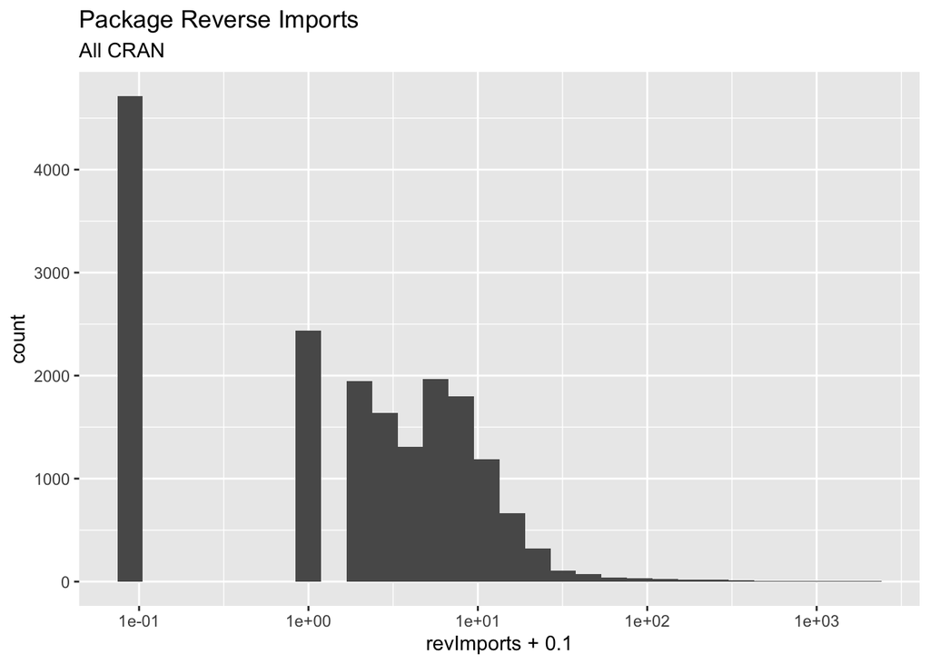

```r
dg <- miniCRAN::makeDepGraph(ap$package, suggests = FALSE)
dgr <- graph.reverse(dg)

ap_df <- left_join(ap,
                data.frame(package = V(dg)$name,
                           revImports=degree(delete_edges(dg, E(dg)[which(E(dg)$type!="Imports")])),
                           revDeps=degree(delete_edges(dg, E(dg)[which(E(dg)$type!="Depends")])),
                           pageRank = page_rank(dgr, directed = TRUE)[[1]]
                           )
                )
ap_df %>%
  ggplot(aes(x=revImports+0.1)) +
  geom_histogram() + scale_x_log10() +
  ggtitle("Package Reverse Imports","All CRAN")
```

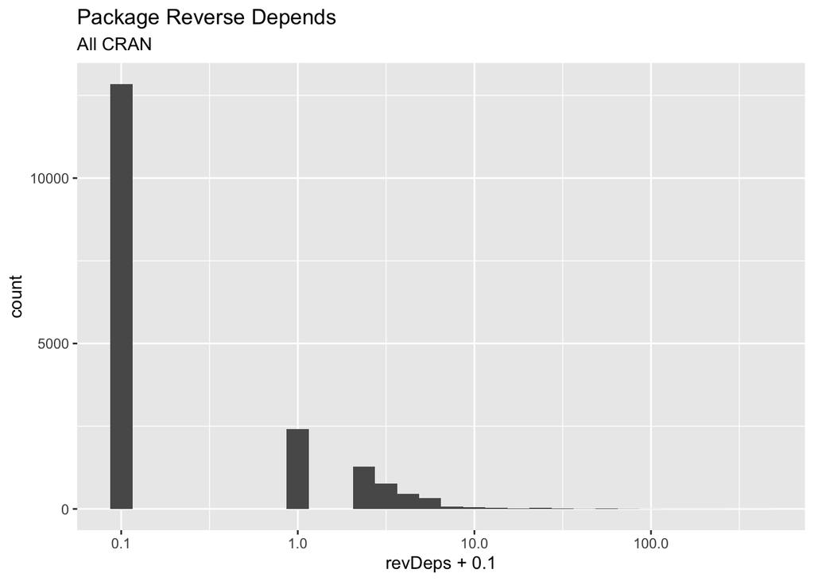

```r
ap_df %>%
  ggplot(aes(x=revDeps+0.1)) +
  geom_histogram() + scale_x_log10() +
  ggtitle("Package Reverse Depends","All CRAN")
```

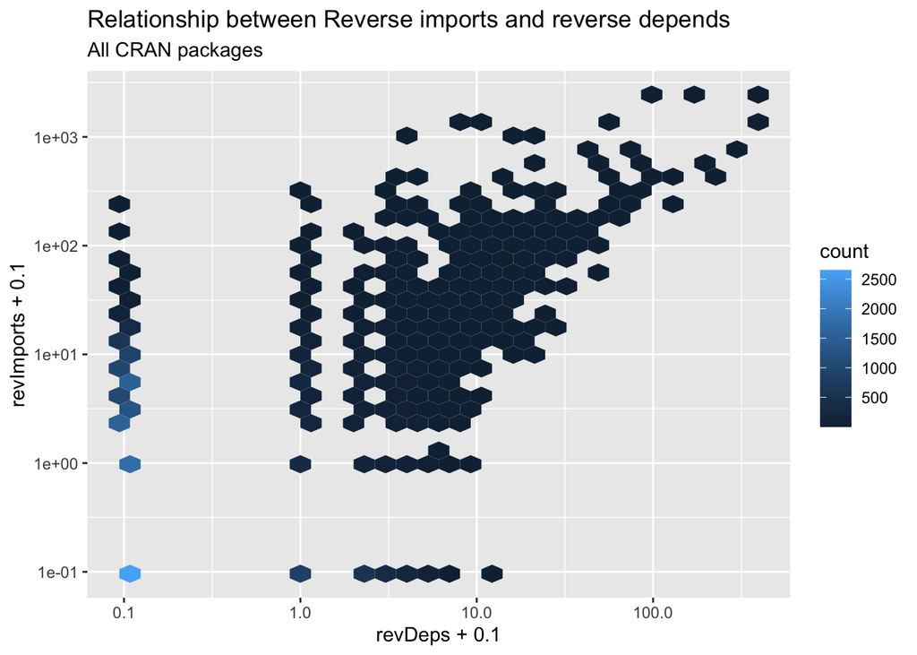

```r
ap_df %>%
  ggplot(aes(x=revDeps+0.1, y=revImports+0.1)) + geom_hex() +
  scale_x_log10() + scale_y_log10() + ggtitle("Relationship between Reverse imports and reverse depends", "All CRAN packages")
```

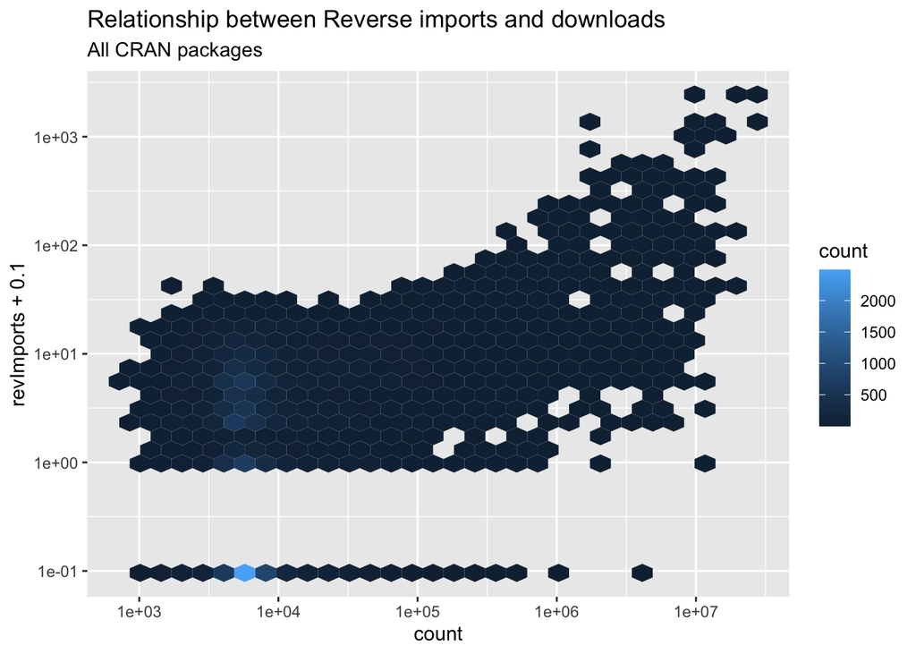

```r
ap_df %>%
  ggplot(aes(x=count, y=revImports+0.1)) + geom_hex() +
  scale_x_log10() + scale_y_log10() + ggtitle("Relationship between Reverse imports and downloads", "All CRAN packages")
```

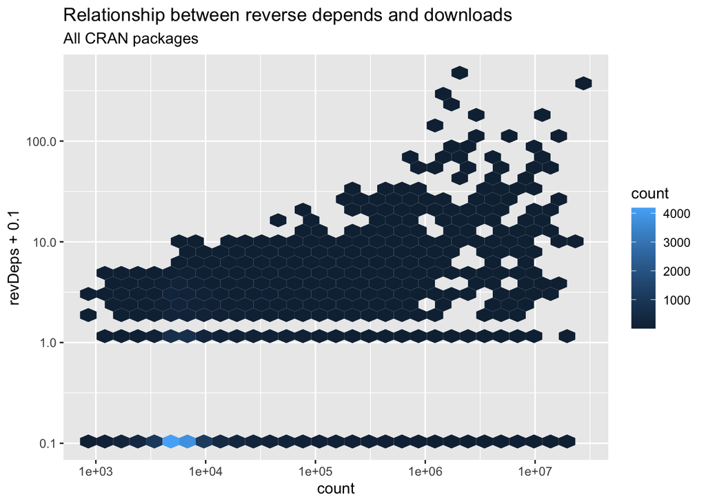

```r
ap_df %>%
  ggplot(aes(x=count, y=revDeps+0.1)) + geom_hex() +
  scale_x_log10() + scale_y_log10() + ggtitle("Relationship between reverse depends and downloads", "All CRAN packages")
```

## Packages selected

Using the criteria above we have selected the following packages, with the aim to keep the list to a few hundred.

```r
ap_df_filtered <- ap_df %>%
  mutate(count_rank=percent_rank(count)) %>%
  group_by(isStat) %>%
  mutate(revDep_rank = percent_rank(revDeps),
         count_rank_g = percent_rank(count)) %>%
  filter((revDeps>0 & revImports==0 & count_rank >=0.99) |
           (isStat==1 & revDep_rank >= 0.75 & count_rank_g >=0.75 ) |
           (isStat==0 & revDep_rank >= 0.98 & count_rank_g >=0.98))


ap_df_filtered %>%
  select(package, inCTV=isStat, downloads=count, revDeps, revImports) %>%
  DT::datatable()
```

|  | package | inCTV | downloads | revDeps | revImports |
| --- | --- | --- | --- | --- | --- |
| 1 | abind | 1 | 3802687 | 27 | 168 |
| 2 | ade4 | 1 | 586209 | 21 | 40 |
| 3 | AER | 1 | 391847 | 10 | 17 |
| 4 | ape | 0 | 745609 | 72 | 165 |
| 5 | arm | 0 | 700014 | 8 | 26 |
| 6 | arules | 1 | 779237 | 13 | 13 |
| 7 | BayesFactor | 1 | 198399 | 4 | 17 |
| 8 | bayesm | 1 | 69335 | 3 | 7 |
| 9 | BiasedUrn | 1 | 107602 | 5 | 7 |
| 10 | bitops | 0 | 3964517 | 10 | 19 |

[output cut: 255 more lines]

```r
saveRDS(ap_df_filtered, "packages_selection_current.rds")
saveRDS(ap_df_filtered, paste0("packages_selection_", gsub("-","", Sys.Date(), ".rds")))
```